# Assignment2

Raghav Atal

4/14/2019

## Reading test data

```r
data <- read.csv('TS regression - data_akbilgic.csv')
head(data)
```

```
##        date          ISE           SP          DAX         FTSE
## 1  5-Jan-09  0.038376187 -0.004679315  0.002193419  0.003894376
## 2  6-Jan-09  0.031812743  0.007786738  0.008455341  0.012865611
## 3  7-Jan-09 -0.026352966 -0.030469134 -0.017833062 -0.028734593
## 4  8-Jan-09 -0.084715902  0.003391364 -0.011726277 -0.000465999
## 5  9-Jan-09  0.009658112 -0.021533208 -0.019872754 -0.012709717
## 6 12-Jan-09 -0.042361155 -0.022822626 -0.013525735 -0.005025533
##         NIKKEI     BOVESPA
## 1  0.000000000  0.03119023
## 2  0.004162452  0.01891958
## 3  0.017292932 -0.03589858
## 4 -0.040061309  0.02828315
## 5 -0.004473502 -0.00976388
## 6 -0.049038532 -0.05384947
```

# Q1

Determine if all the TS are stationary 1. qualitatively 2. quantitatively - use ADF and KPSS from package tseries

## 1. Performing Qualitative tests

```r
colnames(data[,-c(1)])
```

```
## [1] "ISE"     "SP"      "DAX"     "FTSE"    "NIKKEI"  "BOVESPA"
```

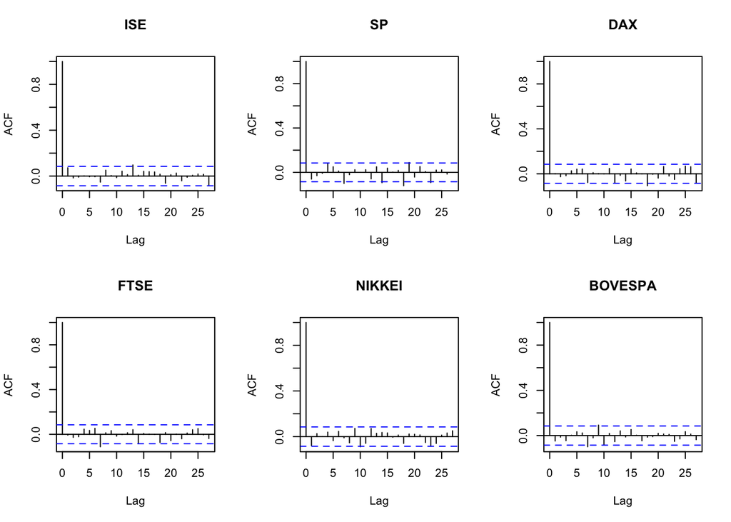

```r
library(tseries)
par(mfrow=c(2,3))

for (col in colnames(data[,-c(1)])){
  acf(data[col])
}
```

#### All ACF plots show stationarity. Therefore, qualitative analysis shows that all indexes have a stationary time series.

## 2. Performing Quantitative tests

```r
adf_test <- c()
kpss_test <- c()
for (col in colnames(data[,-c(1)])){
  adt <- suppressWarnings(adf.test(data[[col]]))
  kpsst <- suppressWarnings(kpss.test(data[[col]]))
  adf_test <- append(adf_test,adt$p.value)
  kpss_test <- append(kpss_test,kpsst$p.value)
}
```

#### ADF Test p-values for all Index Time series

```r
adf_test
```

```
## [1] 0.01 0.01 0.01 0.01 0.01 0.01
```

#### ADF tests rejects the null Hypothesis, hence all Index Time Series are stationary

#### KPSS Test p-values for all Index Time series

```r
kpss_test
```

```
## [1] 0.1 0.1 0.1 0.1 0.1 0.1
```

#### KPSS tests accepts the null Hypothesis, hence all Index Time Series are stationary

# Q2

Split the data into train and test, keeping only the last 10 rows for test (from date 9-Feb-11). Remember to use only train dataset for #3 to #6.

```r
test.data <- tail(data,10)
train.data <- head(data,526)
tail(train.data)
```

```
##         date          ISE           SP          DAX         FTSE
## 521 1-Feb-11  0.035256817  0.016555814  0.014976002  0.016056924
## 522 2-Feb-11  0.014238624 -0.002726279 -0.000083500  0.007074850
## 523 3-Feb-11 -0.027850188  0.002351473  0.001392468 -0.002803881
## 524 4-Feb-11  0.013959227  0.002880096  0.003127022  0.002353787
## 525 7-Feb-11  0.008552888  0.006220742  0.009298107  0.008897506
## 526 8-Feb-11  0.006885706  0.004176098  0.005424862  0.006637976
##           NIKKEI      BOVESPA
## 521  0.003566623  0.018926038
## 522  0.017640939 -0.017230143
## 523 -0.002489383  0.001153964
## 524  0.010694800 -0.022661800
## 525  0.004591322  0.001423858
## 526  0.004139817  0.006237962
```

# Q3

Linearly regress ISE against the remaining 5 stock index returns - determine which coefficients are equal or better than 0.02 (*) level of significance?

```r
lm.model <- lm(ISE~0+.,data=train.data[,2:7])
lm.model.summary <- summary(lm.model)
lm.model.summary$coefficients[,4] <0.02
```

```
##      SP     DAX    FTSE  NIKKEI BOVESPA
##   FALSE    TRUE    TRUE    TRUE   FALSE
```

#### Here we find the SP and BOVESPA are not significant below 0.02 level

# Q4

For the non-significant coefficients, continue to lag by 1 day until all coefficients are significant at 0.01 (*). Use slide() function from package DataCombine. Remember you will need to lag, so you slideBy = -1 each step. How many lags are needed for each independent variable?

```r
library(DataCombine)
train.data.lag <- slide(train.data[,2:7], 'SP', 'SP', slideBy = -2)
```

```
##
## Lagging SP by 2 time units.
```

```r
train.data.lag <- slide(train.data.lag, 'BOVESPA', 'BOVESPA', slideBy = -1)
```

```
##
## Lagging BOVESPA by 1 time units.
```

```r
train.data.df <- train.data.lag
#train.data.df <- train.data.lag[,-c(2,6)]
#Rename lagged column names back to normal index names before runnin linear regression
#colnames(train.data.df)[colnames(train.data.df)=="SP-2"] <- "SP"
#colnames(train.data.df)[colnames(train.data.df)=="BOVESPA-1"] <- "BOVESPA"
head(train.data.df)
```

```
##            ISE           SP          DAX         FTSE       NIKKEI
## 1  0.038376187 -0.004679315  0.002193419  0.003894376  0.000000000
## 2  0.031812743  0.007786738  0.008455341  0.012865611  0.004162452
## 3 -0.026352966 -0.030469134 -0.017833062 -0.028734593  0.017292932
## 4 -0.084715902  0.003391364 -0.011726277 -0.000465999 -0.040061309
## 5  0.009658112 -0.021533208 -0.019872754 -0.012709717 -0.004473502
## 6 -0.042361155 -0.022822626 -0.013525735 -0.005025533 -0.049038532
##       BOVESPA         SP-2   BOVESPA-1
## 1  0.03119023           NA          NA
## 2  0.01891958           NA  0.03119023
## 3 -0.03589858 -0.004679315  0.01891958
## 4  0.02828315  0.007786738 -0.03589858
## 5 -0.00976388 -0.030469134  0.02828315
## 6 -0.05384947  0.003391364 -0.00976388
```

```r
lm.model.lag <- lm(ISE~0+.,data=train.data.df)
summary(lm.model.lag)
```

```
##
## Call:
## lm(formula = ISE ~ 0 + ., data = train.data.df)
##
## Residuals:
##       Min        1Q    Median        3Q       Max
## -0.066468 -0.008631  0.001003  0.009549  0.050541
##
## Coefficients:
##             Estimate Std. Error t value Pr(>|t|)
## SP          -0.01945    0.07554  -0.258  0.79689
## DAX          0.30348    0.09379   3.236  0.00129 **
## FTSE         0.58590    0.10473   5.594 3.59e-08 ***
## NIKKEI       0.22772    0.04904   4.643 4.36e-06 ***
## BOVESPA      0.13510    0.06195   2.181  0.02965 *
## `SP-2`      -0.10756    0.04540  -2.369  0.01820 *
## `BOVESPA-1`  0.22872    0.04611   4.961 9.54e-07 ***
## ---
## Signif. codes:  0 '***' 0.001 '**' 0.01 '*' 0.05 '.' 0.1 ' ' 1
##
## Residual standard error: 0.01476 on 517 degrees of freedom
##   (2 observations deleted due to missingness)
## Multiple R-squared:  0.5226, Adjusted R-squared:  0.5161
## F-statistic: 80.83 on 7 and 517 DF,  p-value: < 2.2e-16
```

# Q5

Find correlations between ISE and each independent variable. Sum the square of the correlations. How does it compare to R-squared from #4?

```r
corr.ss <- sum(cor(na.omit(train.data.df))[1,-c(1)]^2)
corr.ss
```

```
## [1] 1.475955
```

```r
lm.rsquared <- summary(lm.model.lag)$r.squared
lm.rsquared
```

```
## [1] 0.5225521
```

```r
difference <- corr.ss - lm.rsquared
difference
```

```
## [1] 0.9534034
```

# Q6

Concept question 1 - why do you think the R-squared in #4 is so much less than the sum of square of the correlations?

ANS:-

```r
cor(na.omit(train.data.df))
```

```
##                   ISE          SP         DAX        FTSE      NIKKEI
## ISE        1.00000000  0.45163743  0.63252692  0.64876599  0.39343893
## SP         0.45163743  1.00000000  0.68520602  0.65705060  0.13096331
## DAX        0.63252692  0.68520602  1.00000000  0.86812847  0.25882399
## FTSE       0.64876599  0.65705060  0.86812847  1.00000000  0.25431461
## NIKKEI     0.39343893  0.13096331  0.25882399  0.25431461  1.00000000
## BOVESPA    0.44209929  0.72771526  0.58880834  0.59626972  0.17020988
## SP-2      -0.08709912 -0.02917966 -0.01475575 -0.01304941 -0.02478907
## BOVESPA-1  0.30521993 -0.03758834  0.14103962  0.12305276  0.41980778
##               BOVESPA        SP-2   BOVESPA-1
## ISE        0.44209929 -0.08709912  0.30521993
## SP         0.72771526 -0.02917966 -0.03758834
## DAX        0.58880834 -0.01475575  0.14103962
## FTSE       0.59626972 -0.01304941  0.12305276
## NIKKEI     0.17020988 -0.02478907  0.41980778
## BOVESPA    1.00000000 -0.00108225 -0.05382558
## SP-2      -0.00108225  1.00000000 -0.01174427
## BOVESPA-1 -0.05382558 -0.01174427  1.00000000
```

The Rsquared is the explained variance by the model. It is lesser than the sum of squares of individual correlations because there is high correlation amongst the predictor variables. for example DAX and FTSE have 86% correlation Due to multicollinearity the explained variance by the model is less than the sum of individual correlations with predictor variables.

# Q7

Take the test dataset - perform the same lags from #4 and call predict() function using the lm regression object from #4. Why do you need to use the lm function object from #4?

```r
test.data.lag <- slide(test.data[2:7] , 'SP', 'SP', slideBy = -2)
```

```
##
## Lagging SP by 2 time units.
```

```r
test.data.lag <- slide(test.data.lag , 'BOVESPA', 'BOVESPA', slideBy = -1)
```

```
##
## Lagging BOVESPA by 1 time units.
```

```r
pred_values <- predict(lm.model.lag,newdata = test.data.lag)
pred_values
```

```
##           527           528           529           530           531
##            NA            NA  0.0119100195  0.0064199428  0.0001639318
##           532           533           534           535           536
##  0.0079029376  0.0051569181  0.0010149009 -0.0108709737 -0.0105734519
```

Because the lm object from q4 was fitted on the training data to calculate the betas associated with the linear model using the same object in predict function calculates the predicted values based on the betas learned in q4

# Q8

Concept question 2 - what do you find in #1 and why?

Ans:- We find the all the indexes are stationary time series as they have passed both qualitative (ACF) and quantitative(ADF and KPSS) tests for stationarity